# WUM Praca domowa 7

Katarzyna Spalińska

22 maja 2019

## Rozmowa z chat-botem https://kmichael08.github.io

### 1. Czego bot nie zrozumiał a powinien?

- Na początku wybrałam istniejącą już osobę, Rose. Bot niestety nie zrozumiał pytania “How old was Rose?”, dowiedziałam się o wartościach jej zmiennych dopiero po pytaniu “Can I give you personal details to predict?” - czyli też nie do końca takie były moje intencje, ale w odpowiedzi dostałam charakterystykę Rose. Później odkryłam, że mogłam po prostu zadać pytanie “what do you know about me?” i również otrzymałabym odpowiedź na wcześniejsze pytanie o wiek Rose.
- Szczęśliwie na pytanie “Can we predict my chances?” (jako Rose) odpowiedź była dokładnie taka jak być powinna.
- Bot poprawnie odczytał moje intencje po pytaniu “Can I change age?” - zapytał mnie ile mam lat a potem dał mi odpowiedź o tym jakie są moje szanse przeżycia z nowym (starszym) wiekiem. Również poniekąd poprawnie zinterpretował pytanie “The chance is lower now, why?” odpowiadając wykresem Break Down - jednak moje pytanie bardziej kładło nacisk na wpływ zmiany wieku na zmianę predykcji, więc może bardziej pasowałby wykres Ceteris Paribus?
- z niezrozumiałych dla mnie przyczyn na pytanie “Older age means lower chance to survive?” dostałam w odpowiedzi wykres Ceteris Paribus ale dla zmiennej “class”. Wtedy dowiedziałam się też, że mogę zadawać pytania “What if..” dla wybranych zmiennych i te pytania dawały satysfakcjonujące odpowiedzi.
- Po mojej prośbie o zmianę wartości płeć bot zrozumiał moje pytanie “Why gender changes the chances so much?” odpowiadając wykresem Break Down; tak samo odpowiedział na pytanie “Which variable has most impact on prediction?”, co uważam za poprawną interpretację.
- Zrozumiał również pytanie “What if gender was different”, odpowiadając wykresem Ceteris Paribus - może jednak byłby on bardziej czytelny, gdyby skala zaczynała się od 0?

Wykres Ceteris Caribus dla płci:

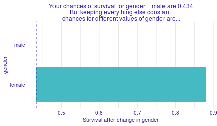

- na początku wybrałam charakter Rose, a potem chciałam zostać Jackiem, ale niestety bot nie zrozumiał prośby “Can I be Jack now?”..

### 2. Jakie nowe intencje mógłby rozpoznawać lepiej?

2.1. Mógłby znać nieco więcej pytań proszących o przypomnienie wartości poszczególnych zmiennych. Oczywiście po odkryciu pytania “What do you know about me?” można uzyskać dokładnie ten sam efekt, ale myślę że mogłoby to dodać rozmowie naturalności.

Poprawnie odpowiada na pytania:

- “How old am I?”
- “What do you know about me?”

Niepoprawnie:

- “What is my age?”
- “What is my gender?”
- “How old was Rose?” (przy czym “How old IS Rose?” działa poprawnie)

2.2. Mógłby znać odpowiedzi na pytania:

- “Can you explain/tell me what is Break Down plot?”.

Przy pojawieniu się wykresu pojawia się krótki opis, ale mimo wszystko ktoś mógłby chcieć dowiedzieć się więcej.

2.3. Mógłby znać odpowiedzi na pytania:

- What is worst/best scenario?

W kontekście tego jakie powinny być wartości zmiennych, aby dać możliwie najwyższe/najniższe predykcje